# credit card segmentation

Jeevan Hemmanna B

17 January, 2020

## Problem Statement

This case requires trainees to develop a customer segmentation to define marketing strategy. The sample dataset summarizes the usage behaviour of about 9000 active credit card holders during the last 6 months. The file is at a customer level with 18 behavioural variables.

## Data PreProcessing

Here we are now doing a data preprocessing and we will be cresting the New KPI’s and also we will be doing data scaling and treating the outliers.

```r
set.seed(25)
credit =  read.csv('credit-card-data.csv',header = T , na.strings = c(" ","","NA","NAN"))

str(credit)
```

```
## 'data.frame':    8950 obs. of  18 variables:
##  $ CUST_ID                         : Factor w/ 8950 levels "C10001","C10002",..: 1 2 3 4 5 6 7 8 9 10 ...
##  $ BALANCE                         : num  40.9 3202.5 2495.1 1666.7 817.7 ...
##  $ BALANCE_FREQUENCY               : num  0.818 0.909 1 0.636 1 ...
##  $ PURCHASES                       : num  95.4 0 773.2 1499 16 ...
##  $ ONEOFF_PURCHASES                : num  0 0 773 1499 16 ...
##  $ INSTALLMENTS_PURCHASES          : num  95.4 0 0 0 0 ...
##  $ CASH_ADVANCE                    : num  0 6443 0 206 0 ...
##  $ PURCHASES_FREQUENCY             : num  0.1667 0 1 0.0833 0.0833 ...
##  $ ONEOFF_PURCHASES_FREQUENCY      : num  0 0 1 0.0833 0.0833 ...
##  $ PURCHASES_INSTALLMENTS_FREQUENCY: num  0.0833 0 0 0 0 ...
##  $ CASH_ADVANCE_FREQUENCY          : num  0 0.25 0 0.0833 0 ...
##  $ CASH_ADVANCE_TRX                : int  0 4 0 1 0 0 0 0 0 0 ...
##  $ PURCHASES_TRX                   : int  2 0 12 1 1 8 64 12 5 3 ...
##  $ CREDIT_LIMIT                    : num  1000 7000 7500 7500 1200 1800 13500 2300 7000 11000 ...
##  $ PAYMENTS                        : num  202 4103 622 0 678 ...
##  $ MINIMUM_PAYMENTS                : num  140 1072 627 NA 245 ...
##  $ PRC_FULL_PAYMENT                : num  0 0.222 0 0 0 ...
##  $ TENURE                          : int  12 12 12 12 12 12 12 12 12 12 ...
```

```r
summary(credit)
```

```
##     CUST_ID        BALANCE        BALANCE_FREQUENCY   PURCHASES
##  C10001 :   1   Min.   :    0.0   Min.   :0.0000    Min.   :    0.00
##  C10002 :   1   1st Qu.:  128.3   1st Qu.:0.8889    1st Qu.:   39.63
##  C10003 :   1   Median :  873.4   Median :1.0000    Median :  361.28
##  C10004 :   1   Mean   : 1564.5   Mean   :0.8773    Mean   : 1003.20
##  C10005 :   1   3rd Qu.: 2054.1   3rd Qu.:1.0000    3rd Qu.: 1110.13
##  C10006 :   1   Max.   :19043.1   Max.   :1.0000    Max.   :49039.57
##  (Other):8944
##  ONEOFF_PURCHASES  INSTALLMENTS_PURCHASES  CASH_ADVANCE     PURCHASES_FREQUENCY
##  Min.   :    0.0   Min.   :    0.0        Min.   :    0.0   Min.   :0.00000
##  1st Qu.:    0.0   1st Qu.:    0.0        1st Qu.:    0.0   1st Qu.:0.08333
##  Median :   38.0   Median :   89.0        Median :    0.0   Median :0.50000
##  Mean   :  592.4   Mean   :  411.1        Mean   :  978.9   Mean   :0.49035
##  3rd Qu.:  577.4   3rd Qu.:  468.6        3rd Qu.: 1113.8   3rd Qu.:0.91667
##  Max.   :40761.2   Max.   :22500.0        Max.   :47137.2   Max.   :1.00000
##
##  ONEOFF_PURCHASES_FREQUENCY PURCHASES_INSTALLMENTS_FREQUENCY
##  Min.   :0.00000            Min.   :0.0000
##  1st Qu.:0.00000            1st Qu.:0.0000
##  Median :0.08333            Median :0.1667
##  Mean   :0.20246            Mean   :0.3644
##  3rd Qu.:0.30000            3rd Qu.:0.7500
##  Max.   :1.00000            Max.   :1.0000
##
##  CASH_ADVANCE_FREQUENCY CASH_ADVANCE_TRX  PURCHASES_TRX     CREDIT_LIMIT
##  Min.   :0.0000         Min.   :  0.000   Min.   :  0.00   Min.   :   50
##  1st Qu.:0.0000         1st Qu.:  0.000   1st Qu.:  1.00   1st Qu.: 1600
##  Median :0.0000         Median :  0.000   Median :  7.00   Median : 3000
##  Mean   :0.1351         Mean   :  3.249   Mean   : 14.71   Mean   : 4494
##  3rd Qu.:0.2222         3rd Qu.:  4.000   3rd Qu.: 17.00   3rd Qu.: 6500
##  Max.   :1.5000         Max.   :123.000   Max.   :358.00   Max.   :30000
##                                                            NA's   :1
##     PAYMENTS       MINIMUM_PAYMENTS   PRC_FULL_PAYMENT     TENURE
##  Min.   :    0.0   Min.   :    0.02   Min.   :0.0000   Min.   : 6.00
##  1st Qu.:  383.3   1st Qu.:  169.12   1st Qu.:0.0000   1st Qu.:12.00
##  Median :  856.9   Median :  312.34   Median :0.0000   Median :12.00
##  Mean   : 1733.1   Mean   :  864.21   Mean   :0.1537   Mean   :11.52
##  3rd Qu.: 1901.1   3rd Qu.:  825.49   3rd Qu.:0.1429   3rd Qu.:12.00
##  Max.   :50721.5   Max.   :76406.21   Max.   :1.0000   Max.   :12.00
##                    NA's   :313
```

```r
missing_val = data.frame(apply(credit, 2, function(x){sum(is.na(x))}))
missing_val
```

```
##                                  apply.credit..2..function.x...
## CUST_ID                                                       0
## BALANCE                                                       0
## BALANCE_FREQUENCY                                             0
## PURCHASES                                                     0
## ONEOFF_PURCHASES                                              0
## INSTALLMENTS_PURCHASES                                        0
## CASH_ADVANCE                                                  0
## PURCHASES_FREQUENCY                                           0
## ONEOFF_PURCHASES_FREQUENCY                                    0
## PURCHASES_INSTALLMENTS_FREQUENCY                              0
## CASH_ADVANCE_FREQUENCY                                        0
## CASH_ADVANCE_TRX                                              0
## PURCHASES_TRX                                                 0
## CREDIT_LIMIT                                                  1
## PAYMENTS                                                      0
## MINIMUM_PAYMENTS                                            313
## PRC_FULL_PAYMENT                                              0
## TENURE                                                        0
```

```r
credit$CREDIT_LIMIT[is.na(credit$CREDIT_LIMIT)] = median(credit$CREDIT_LIMIT, na.rm = T)
credit$MINIMUM_PAYMENTS[is.na(credit$MINIMUM_PAYMENTS)] = median(credit$MINIMUM_PAYMENTS, na.rm = T)
sum(is.na(credit))
```

```
## [1] 0
```

## Deriving New KPI’s

Here we are deriving New KPI as asked in a problem statements.

- Monthly average perchase is purchases by tenure
- monthly cash advance is cash advance by tenure
- creating categories by using One_off purchase and installment purchases
- limit usage is basically ratio of balance to limit usage.Lower limit usage implies cutomers are maintaing thier balance properly and it also mean that they have a good credit score
- Pay_minPay is the ratio of payments to minimum payments

These are the new KPI’s formed

```r
#New Variables creation#
credit$Monthly_Avg_PURCHASES <- credit$PURCHASES/(credit$TENURE)
credit$Monthly_CASH_ADVANCE <- credit$CASH_ADVANCE/(credit$TENURE)
credit$LIMIT_USAGE <- credit$BALANCE/credit$CREDIT_LIMIT
credit$MIN_PAYMENTS_RATIO <- credit$PAYMENTS/credit$MINIMUM_PAYMENTS

credit$PURCHASE_TYPE <- dplyr::case_when(
  credit$ONEOFF_PURCHASES == 0 & credit$INSTALLMENTS_PURCHASES == 0 ~ 'none',
  credit$ONEOFF_PURCHASES > 0 & credit$INSTALLMENTS_PURCHASES == 0 ~ 'oneoff',
  credit$ONEOFF_PURCHASES > 0 & credit$INSTALLMENTS_PURCHASES > 0 ~ 'both_oneoff_installment',
  credit$ONEOFF_PURCHASES ==0 & credit$INSTALLMENTS_PURCHASES > 0 ~ 'installment'
)
credit$PURCHASE_TYPE  <- as.factor(credit$PURCHASE_TYPE)

colnames(credit)
```

```
##  [1] "CUST_ID"                          "BALANCE"
##  [3] "BALANCE_FREQUENCY"                "PURCHASES"
##  [5] "ONEOFF_PURCHASES"                 "INSTALLMENTS_PURCHASES"
##  [7] "CASH_ADVANCE"                     "PURCHASES_FREQUENCY"
##  [9] "ONEOFF_PURCHASES_FREQUENCY"       "PURCHASES_INSTALLMENTS_FREQUENCY"
## [11] "CASH_ADVANCE_FREQUENCY"           "CASH_ADVANCE_TRX"
## [13] "PURCHASES_TRX"                    "CREDIT_LIMIT"
## [15] "PAYMENTS"                         "MINIMUM_PAYMENTS"
## [17] "PRC_FULL_PAYMENT"                 "TENURE"
## [19] "Monthly_Avg_PURCHASES"            "Monthly_CASH_ADVANCE"
## [21] "LIMIT_USAGE"                      "MIN_PAYMENTS_RATIO"
## [23] "PURCHASE_TYPE"
```

```r
str(credit)
```

```
## 'data.frame':    8950 obs. of  23 variables:
##  $ CUST_ID                         : Factor w/ 8950 levels "C10001","C10002",..: 1 2 3 4 5 6 7 8 9 10 ...
##  $ BALANCE                         : num  40.9 3202.5 2495.1 1666.7 817.7 ...
##  $ BALANCE_FREQUENCY               : num  0.818 0.909 1 0.636 1 ...
##  $ PURCHASES                       : num  95.4 0 773.2 1499 16 ...
##  $ ONEOFF_PURCHASES                : num  0 0 773 1499 16 ...
##  $ INSTALLMENTS_PURCHASES          : num  95.4 0 0 0 0 ...
##  $ CASH_ADVANCE                    : num  0 6443 0 206 0 ...
##  $ PURCHASES_FREQUENCY             : num  0.1667 0 1 0.0833 0.0833 ...
##  $ ONEOFF_PURCHASES_FREQUENCY      : num  0 0 1 0.0833 0.0833 ...
##  $ PURCHASES_INSTALLMENTS_FREQUENCY: num  0.0833 0 0 0 0 ...
##  $ CASH_ADVANCE_FREQUENCY          : num  0 0.25 0 0.0833 0 ...
##  $ CASH_ADVANCE_TRX                : int  0 4 0 1 0 0 0 0 0 0 ...
##  $ PURCHASES_TRX                   : int  2 0 12 1 1 8 64 12 5 3 ...
##  $ CREDIT_LIMIT                    : num  1000 7000 7500 7500 1200 1800 13500 2300 7000 11000 ...
##  $ PAYMENTS                        : num  202 4103 622 0 678 ...
##  $ MINIMUM_PAYMENTS                : num  140 1072 627 312 245 ...
##  $ PRC_FULL_PAYMENT                : num  0 0.222 0 0 0 ...
##  $ TENURE                          : int  12 12 12 12 12 12 12 12 12 12 ...
##  $ Monthly_Avg_PURCHASES           : num  7.95 0 64.43 124.92 1.33 ...
##  $ Monthly_CASH_ADVANCE            : num  0 536.9 0 17.1 0 ...
##  $ LIMIT_USAGE                     : num  0.0409 0.4575 0.3327 0.2222 0.6814 ...
##  $ MIN_PAYMENTS_RATIO              : num  1.447 3.826 0.992 0 2.771 ...
##  $ PURCHASE_TYPE                   : Factor w/ 4 levels "both_oneoff_installment",..: 2 3 4 4 4 2 1 2 1 4 ...
```

```r
credit_copy = credit
```

## preparing for Machine Learning

Here we will be preparing the data for machine learning algorithm. we Need to convert the purchase_type column into binary variable.

```r
transformed_variables <- c("BALANCE","BALANCE_FREQUENCY",
                           "PURCHASES", "ONEOFF_PURCHASES", "INSTALLMENTS_PURCHASES",
                           "CASH_ADVANCE","PURCHASES_FREQUENCY","ONEOFF_PURCHASES_FREQUENCY",
                           "PURCHASES_INSTALLMENTS_FREQUENCY","CASH_ADVANCE_FREQUENCY",
                           "CASH_ADVANCE_TRX", "PURCHASES_TRX", "CREDIT_LIMIT",
                           "PAYMENTS", "MINIMUM_PAYMENTS","PRC_FULL_PAYMENT","TENURE",                                        "Monthly_Avg_PURCHASES","Monthly_CASH_ADVANCE",
                           "LIMIT_USAGE","MIN_PAYMENTS_RATIO") # vector of variables to be log transformed

credit_transformed_data <- credit %>%                           # preserve original dataset
  .[,-c(1,23)] %>%                                              #dropping CUST_ID and PURCHASE_TYPE
  mutate_at(vars(transformed_variables), funs(log(1 + .))) %>%  # add 1 to each value to avoid log0
  mutate_at(c(2:17), funs(c(scale(.))))                         # scale all numeric variables to mean of 0 & sd = 1
#taking only the variable which we dont use for KPI
credit_transformed_selected <- credit_transformed_data[,-c(1,3,6,17,14,15,16,13)]

colnames(credit_transformed_selected)
```

```
##  [1] "BALANCE_FREQUENCY"                "ONEOFF_PURCHASES"
##  [3] "INSTALLMENTS_PURCHASES"           "PURCHASES_FREQUENCY"
##  [5] "ONEOFF_PURCHASES_FREQUENCY"       "PURCHASES_INSTALLMENTS_FREQUENCY"
##  [7] "CASH_ADVANCE_FREQUENCY"           "CASH_ADVANCE_TRX"
##  [9] "PURCHASES_TRX"                    "Monthly_Avg_PURCHASES"
## [11] "Monthly_CASH_ADVANCE"             "LIMIT_USAGE"
## [13] "MIN_PAYMENTS_RATIO"
```

```r
binary_purchase_type <- to.dummy(credit$PURCHASE_TYPE, "purchase_type")

credit_transformed_selected <- cbind(credit_transformed_selected,binary_purchase_type)

colnames(credit_transformed_selected)
```

```
##  [1] "BALANCE_FREQUENCY"
##  [2] "ONEOFF_PURCHASES"
##  [3] "INSTALLMENTS_PURCHASES"
##  [4] "PURCHASES_FREQUENCY"
##  [5] "ONEOFF_PURCHASES_FREQUENCY"
##  [6] "PURCHASES_INSTALLMENTS_FREQUENCY"
##  [7] "CASH_ADVANCE_FREQUENCY"
##  [8] "CASH_ADVANCE_TRX"
##  [9] "PURCHASES_TRX"
## [10] "Monthly_Avg_PURCHASES"
## [11] "Monthly_CASH_ADVANCE"
## [12] "LIMIT_USAGE"
## [13] "MIN_PAYMENTS_RATIO"
## [14] "purchase_type.both_oneoff_installment"
## [15] "purchase_type.installment"
## [16] "purchase_type.none"
## [17] "purchase_type.oneoff"
```

```r
cormat <- round(cor(credit_transformed_selected),3)
credit_corr <- melt(cormat)
```

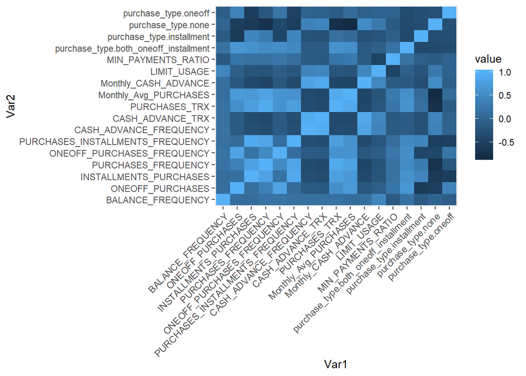

```r
ggplot(data = credit_corr,aes (x = Var1,y = Var2,fill = value)) +
theme(axis.text.x = element_text(angle = 45, vjust = 1,size = 9, hjust = 1)) +
geom_tile()
```

By seeing the heatmap we can conclude that number of variable is too much and we need to reduce the number of variable.

## Standardrizing and scaling of the data

We can reduce the number of variable by using the PCA (principal Component Algorithm). For PCA to work we need to scale the data and then we will be using the PCA. Before Applying the PCA we need to find the optimal value for number of component. we will be using the elbow method to find the optimal number of component

```r
credit_scale = scale(credit_transformed_selected)

credit_scale = as.data.frame(credit_scale)
dim(credit_scale)
```

```
## [1] 8950   17
```

```r
credit_pca <- prcomp(credit_scale)

names(credit_pca)
```

```
## [1] "sdev"     "rotation" "center"   "scale"    "x"
```

```r
credit_pca$center
```

```
##                     BALANCE_FREQUENCY                      ONEOFF_PURCHASES
##                         -7.713026e-18                          9.636922e-19
##                INSTALLMENTS_PURCHASES                   PURCHASES_FREQUENCY
##                         -3.785593e-17                          4.267691e-17
##            ONEOFF_PURCHASES_FREQUENCY      PURCHASES_INSTALLMENTS_FREQUENCY
##                          3.670365e-17                          6.558999e-18
##                CASH_ADVANCE_FREQUENCY                      CASH_ADVANCE_TRX
##                          1.181938e-17                         -1.832178e-17
##                         PURCHASES_TRX                 Monthly_Avg_PURCHASES
##                         -1.997006e-17                         -4.203419e-17
##                  Monthly_CASH_ADVANCE                           LIMIT_USAGE
##                         -2.942343e-18                          1.892884e-18
##                    MIN_PAYMENTS_RATIO purchase_type.both_oneoff_installment
##                         -1.318545e-17                          1.190854e-18
##             purchase_type.installment                    purchase_type.none
##                         -9.923781e-17                          3.101182e-17
##                  purchase_type.oneoff
##                         -1.935137e-17
```

```r
credit_pca$scale
```

```
## [1] FALSE
```

```r
credit_pca$rotation
```

```
##                                               PC1          PC2         PC3
## BALANCE_FREQUENCY                      0.02970710  0.240072217 -0.26313956
## ONEOFF_PURCHASES                       0.21410721  0.406078184  0.23916545
## INSTALLMENTS_PURCHASES                 0.31205063 -0.098403659 -0.31562528
## PURCHASES_FREQUENCY                    0.34582323  0.015813410 -0.16284334
## ONEOFF_PURCHASES_FREQUENCY             0.21470195  0.362207806  0.16322234
## PURCHASES_INSTALLMENTS_FREQUENCY       0.29545081 -0.112002477 -0.33002935
## CASH_ADVANCE_FREQUENCY                -0.21433583  0.286073833 -0.27858553
## CASH_ADVANCE_TRX                      -0.22939348  0.291555606 -0.28508932
## PURCHASES_TRX                          0.35550341  0.106624771 -0.10274279
## Monthly_Avg_PURCHASES                  0.34599214  0.141635391  0.02398613
## Monthly_CASH_ADVANCE                  -0.24386117  0.264317622 -0.25742721
## LIMIT_USAGE                           -0.14630190  0.235709775 -0.25127813
## MIN_PAYMENTS_RATIO                     0.11963162  0.021328016  0.13635689
## purchase_type.both_oneoff_installment  0.24139215  0.273675977 -0.13193476
## purchase_type.installment              0.08220908 -0.443375470 -0.20868331
## purchase_type.none                    -0.31028278 -0.005213539 -0.09691138
## purchase_type.oneoff                  -0.04213752  0.167737275  0.47274947
##                                                PC4          PC5          PC6
## BALANCE_FREQUENCY                      0.353548687  0.228680754  0.693815814
## ONEOFF_PURCHASES                      -0.001519524  0.023197008 -0.129094254
## INSTALLMENTS_PURCHASES                -0.087982599  0.002181369 -0.115223015
## PURCHASES_FREQUENCY                    0.074616666 -0.115947716  0.081878633
## ONEOFF_PURCHASES_FREQUENCY            -0.036303132  0.051279437  0.097299004
## PURCHASES_INSTALLMENTS_FREQUENCY      -0.023502025 -0.025871312 -0.006730740
## CASH_ADVANCE_FREQUENCY                -0.096352556 -0.360132311 -0.066588914
## CASH_ADVANCE_TRX                      -0.103484065 -0.332752510 -0.082307035
## PURCHASES_TRX                          0.054296296 -0.104970995  0.009401792
## Monthly_Avg_PURCHASES                  0.079372898 -0.194146654 -0.015878030
## Monthly_CASH_ADVANCE                  -0.135291816 -0.268026007 -0.058258298
## LIMIT_USAGE                            0.431681652  0.181884667 -0.024297511
## MIN_PAYMENTS_RATIO                    -0.591561004 -0.215445825  0.572466894
## purchase_type.both_oneoff_installment -0.254709583  0.340849320 -0.294708307
## purchase_type.installment              0.190829116 -0.353821446  0.086086800
## purchase_type.none                    -0.245103766  0.342221935  0.176809261
## purchase_type.oneoff                   0.338548865 -0.362584507  0.060697768
##                                               PC7          PC8          PC9
## BALANCE_FREQUENCY                      0.09173787 -0.431064339 -0.112621289
## ONEOFF_PURCHASES                      -0.11207671 -0.108809159 -0.007506005
## INSTALLMENTS_PURCHASES                -0.15801822 -0.074729483 -0.179761704
```

[output cut: 53 more lines]

```
## INSTALLMENTS_PURCHASES                 0.526958878  1.546913e-14
## PURCHASES_FREQUENCY                    0.216924086 -5.779553e-15
## ONEOFF_PURCHASES_FREQUENCY            -0.110616285  5.527948e-15
## PURCHASES_INSTALLMENTS_FREQUENCY      -0.184999143  7.653131e-15
## CASH_ADVANCE_FREQUENCY                 0.008681222 -1.272357e-15
## CASH_ADVANCE_TRX                      -0.013183035  1.595619e-15
## PURCHASES_TRX                         -0.023146276 -6.874869e-15
## Monthly_Avg_PURCHASES                 -0.447156988  2.597173e-15
## Monthly_CASH_ADVANCE                   0.005866518  7.366525e-16
## LIMIT_USAGE                            0.003086279 -2.670582e-16
## MIN_PAYMENTS_RATIO                    -0.001062543  1.690909e-16
## purchase_type.both_oneoff_installment -0.272490715 -5.360651e-01
## purchase_type.installment              0.065374536 -5.035909e-01
## purchase_type.none                     0.175643204 -4.864236e-01
## purchase_type.oneoff                   0.058763213 -4.716169e-01
```

```r
dim(credit_pca$x)
```

```
## [1] 8950   17
```

```r
std_dev <- credit_pca$sdev
pca_var <- std_dev^2

pca_varex <- pca_var/sum(pca_var)
```

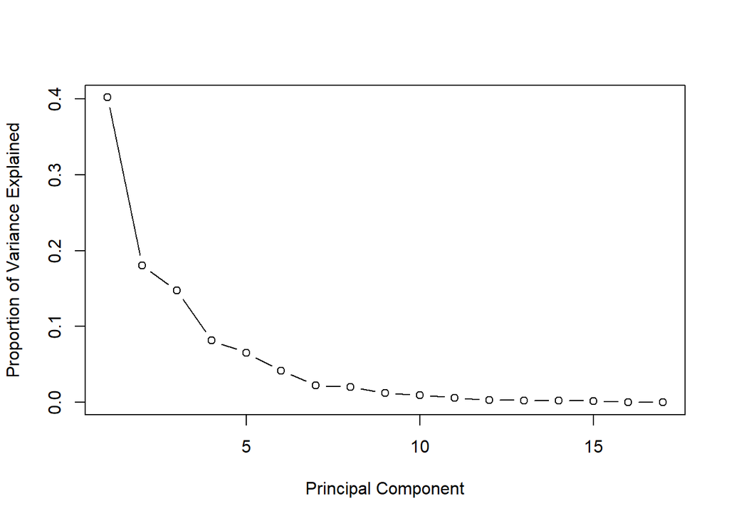

```r
plot(pca_varex, xlab = "Principal Component",
   ylab = "Proportion of Variance Explained",
   type = "b")
```

This plot tells us that selecting 5 components we can preserve something around 87% of the total variance of the data. It makes sense, we’ll not use 100% of our variance, because it denotes all components, and we want only the principal ones. With this information in our hands, we can implement the PCA for 5 best components.

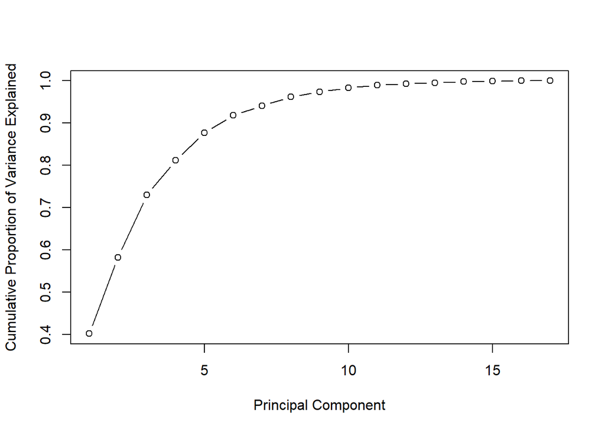

```r
plot(cumsum(pca_varex), xlab = "Principal Component",
   ylab = "Cumulative Proportion of Variance Explained",
   type = "b")
```

This plot shows that 5 components results in variance close to ~ 87%. Therefore, in this case, we’ll select number of components as 5 [PC1 to PC5] and proceed to the modeling stage. This completes the steps to implement PCA on train data. For modeling, we’ll use these 5 components as predictor variables and follow the normal procedures.

```r
credit_pca_data <- data.frame(credit_pca$x)
credit_pca_data <- credit_pca_data[,1:5]
dim(credit_pca_data)
```

```
## [1] 8950    5
```

## Clustering Algorithm - K Means Clustering

Now Our data is ready after we have done the feature selection and scaling of the data.

Before we start the KMeans we need find the optimal cluster value.for the we will be elbow method to find the optimal number of cluster.

```r
kmean_withinss <- function(k) {
cluster <- kmeans(credit_pca_data, k)
return (cluster$tot.withinss)
}

max_k <- 10
wss <- sapply(2:max_k, kmean_withinss)

# Create a data frame to plot the graph
elbow <-data.frame(2:max_k, wss)
```

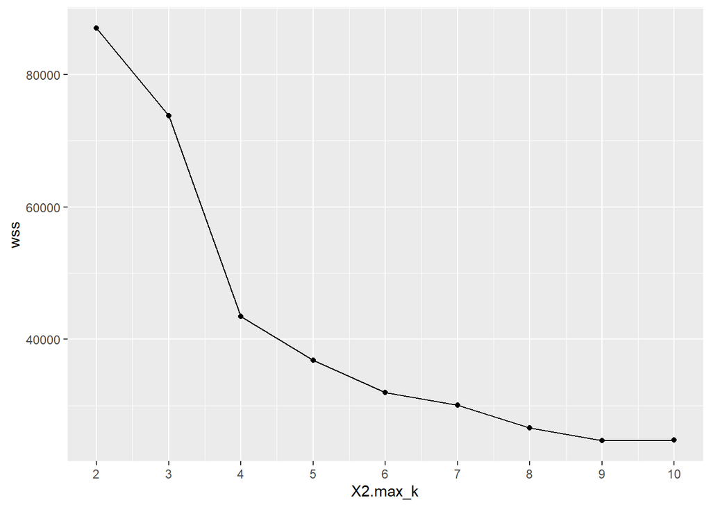

```r
ggplot(elbow, aes(x = X2.max_k, y = wss)) +
geom_point() +
geom_line() +
scale_x_continuous(breaks = seq(1, 20, by = 1))
```

From the graph, you can see the optimal k is 4, where the curve is starting to have a diminishing return. Once you have our optimal k, you run the algorithm with k equals to 4 and evaluate the clusters.

## Applying the K value 4

```r
pc_cluster_4 <-kmeans(credit_pca_data, 4)
cluster_df <- (pc_cluster_4$cluster)
pc_cluster_4$centers
```

```
##          PC1         PC2        PC3        PC4        PC5
## 1 -0.5469527  0.99148953  2.3044494  0.9049383 -0.7747818
## 2  1.0192177 -2.37441234 -0.8745912  0.4503346 -0.6573398
## 3 -3.8635229 -0.02076308 -0.4779493 -0.6005808  0.6456682
## 4  2.4760461  1.26016466 -0.4971120 -0.5235628  0.5681826
```

```r
pc_cluster_4$size
```

```
## [1] 1874 2228 2090 2758
```

```r
center <-pc_cluster_4$centers
center
```

```
##          PC1         PC2        PC3        PC4        PC5
## 1 -0.5469527  0.99148953  2.3044494  0.9049383 -0.7747818
## 2  1.0192177 -2.37441234 -0.8745912  0.4503346 -0.6573398
## 3 -3.8635229 -0.02076308 -0.4779493 -0.6005808  0.6456682
## 4  2.4760461  1.26016466 -0.4971120 -0.5235628  0.5681826
```

```r
# create dataset with the cluster number
cluster <- c(1: 4)
center_df <- data.frame(cluster, center)
# Reshape the data
center_reshape <- gather(center_df, features, values, PC1:PC5)
head(center_reshape)
```

```
##   cluster features     values
## 1       1      PC1 -0.5469527
## 2       2      PC1  1.0192177
## 3       3      PC1 -3.8635229
## 4       4      PC1  2.4760461
## 5       1      PC2  0.9914895
## 6       2      PC2 -2.3744123
```

```r
cluster_scatter <- cbind(credit_pca_data,pc_cluster_4$cluster)
names(cluster_scatter)[6] <- "Cluster"
```

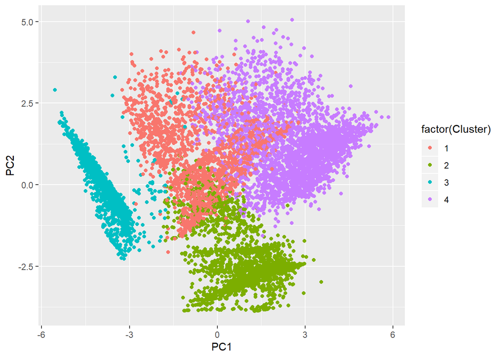

```r
ggplot(data=cluster_scatter, aes(x=PC1, y=PC2, color=factor(Cluster))) +
geom_point()
```

From the scatter plot we can see that we have 4 cluster here and we each data point classified into different cluster.

To get a clear idea of how observation are classified into different cluster we will using the original data without the varibale which are used to create new KPI’s and then adding the cluster classification which we get from the kMeans algorithm and then we will be grouping the data by cluster and we will be summarizing the other variable by mean and checking how well all the observation are classified.

```r
col_kpi=c('CASH_ADVANCE_TRX', 'PURCHASES_TRX', 'Monthly_Avg_PURCHASES',
        'Monthly_CASH_ADVANCE', 'LIMIT_USAGE', 'MIN_PAYMENTS_RATIO')
cluster_4 <- credit[,col_kpi]
cluster_4 <- cbind(cluster_4,binary_purchase_type)
cluster_4 <- cbind(cluster_4,cluster_df)
cluster_4[1:10,]
```

```
##    CASH_ADVANCE_TRX PURCHASES_TRX Monthly_Avg_PURCHASES Monthly_CASH_ADVANCE
## 1                 0             2              7.950000               0.0000
## 2                 4             0              0.000000             536.9121
## 3                 0            12             64.430833               0.0000
## 4                 1             1            124.916667              17.1490
## 5                 0             1              1.333333               0.0000
## 6                 0             8            111.106667               0.0000
## 7                 0            64            590.917500               0.0000
## 8                 0            12             36.350000               0.0000
## 9                 0             5             71.790833               0.0000
## 10                0             3            106.800000               0.0000
##    LIMIT_USAGE MIN_PAYMENTS_RATIO purchase_type.both_oneoff_installment
## 1   0.04090075          1.4465084                                     0
## 2   0.45749535          3.8262415                                     0
## 3   0.33268651          0.9916815                                     0
```

[output cut: 18 more lines]

```r
dim(cluster_4)
```

```
## [1] 8950   11
```

```r
cluster_group_by <- group_by(cluster_4,cluster_df)
cluster_summ <- summarise(cluster_group_by,CASH_ADVANCE_TRX = mean(CASH_ADVANCE_TRX),
                          PURCHASES_TRX= mean(PURCHASES_TRX),
                          Monthly_Avg_PURCHASES = mean(Monthly_Avg_PURCHASES),
                          LIMIT_USAGE = mean(LIMIT_USAGE),
                          Monthly_CASH_ADVANCE = mean(Monthly_CASH_ADVANCE),
                          MIN_PAYMENTS_RATIO = mean(MIN_PAYMENTS_RATIO),
                          purchase_type.both_oneoff_installment = mean(purchase_type.both_oneoff_installment),
                        purchase_type.installment = mean(purchase_type.installment),
                        purchase_type.none = mean(purchase_type.none),
                        purchase_type.oneoff = mean(purchase_type.oneoff))
cluster_summ <- t(cluster_summ)
colnames(cluster_summ) <- c("cluster-1","cluster-2","cluster-3","cluster-4")
cluster_summ
```

```
##                                          cluster-1    cluster-2    cluster-3
## cluster_df                             1.000000000  2.000000000 3.000000e+00
## CASH_ADVANCE_TRX                       2.864994664  1.019299820 6.552632e+00
## PURCHASES_TRX                          7.118996798 12.053859964 4.593301e-02
## Monthly_Avg_PURCHASES                 69.758275903 47.573597589 1.593372e-01
## LIMIT_USAGE                            0.378726746  0.264274761 5.762172e-01
## Monthly_CASH_ADVANCE                  77.843484865 33.489845985 1.862980e+02
## MIN_PAYMENTS_RATIO                     5.561421013 13.402659725 9.927979e+00
## purchase_type.both_oneoff_installment  0.003735326  0.001795332 2.392344e-03
## purchase_type.installment              0.000000000  0.998204668 1.722488e-02
## purchase_type.none                     0.000000000  0.000000000 9.770335e-01
## purchase_type.oneoff                   0.996264674  0.000000000 3.349282e-03
##                                         cluster-4
## cluster_df                              4.0000000
## CASH_ADVANCE_TRX                        2.8071066
## PURCHASES_TRX                          33.1254532
## Monthly_Avg_PURCHASES                 193.6960834
## LIMIT_USAGE                             0.3544875
## Monthly_CASH_ADVANCE                   67.6200059
## MIN_PAYMENTS_RATIO                      7.2686054
## purchase_type.both_oneoff_installment   1.0000000
## purchase_type.installment               0.0000000
## purchase_type.none                      0.0000000
## purchase_type.oneoff                    0.0000000
```

```r
cluster_summ <- cluster_summ[-c(1,2,3),]

cluster_summ <- t(cluster_summ)
cluster_summ <- as.data.frame(cluster_summ)
cluster_summ$Monthly_Avg_PURCHASES <- log(cluster_summ$Monthly_Avg_PURCHASES)
cluster_summ$Monthly_CASH_ADVANCE <- log(cluster_summ$Monthly_CASH_ADVANCE)
cluster_summ <- t(cluster_summ)
cluster_summ <- as.data.frame(cluster_summ)
```

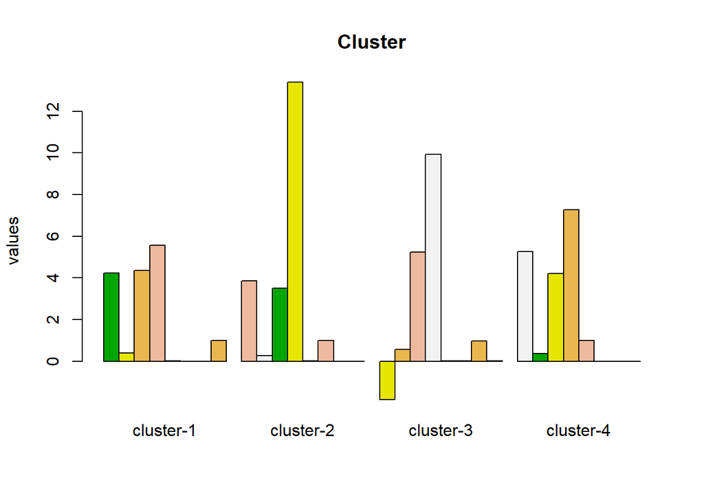

```r
barplot(as.matrix(cluster_summ), main="Cluster", ylab="values", beside=TRUE,
      col=terrain.colors(5))
```

```r
cluster_count <- cluster_scatter %>%
                group_by(Cluster) %>%
                summarise(count_value = n())
cluster_count
```

```
## # A tibble: 4 x 2
##   Cluster count_value
##     <int>       <int>
## 1       1        1874
## 2       2        2228
## 3       3        2090
## 4       4        2758
```

```r
cluster_percentage <- cluster_count %>%
                      mutate(percentage = (count_value/sum(count_value)*100))
cluster_percentage
```

```
## # A tibble: 4 x 3
##   Cluster count_value percentage
##     <int>       <int>      <dbl>
## 1       1        1874       20.9
## 2       2        2228       24.9
## 3       3        2090       23.4
## 4       4        2758       30.8
```

**Some insight on the KMeans cluster-4**

from the above graph we can see that each cluster is clearly showing a distinguishing behaviour within the customers.

- Cluster 4 is the group of customers who have highest Monthly_avg purchases and doing both installment as well as one_off purchases, have comparatively good credit score. This group is about 31% of the total customer base.
- cluster 3 is taking maximum advance_cash and is paying comparatively less minimum payment and poor credit_score & doing no purchase transaction. This group is about 23% of the total customer base.
- Cluster 1 customers are doing maximum One_Off transactions and least payment ratio and credit_score on lower side This group is about 21% of the total customer base.
- Cluster 2 customers have maximum credit score and are paying dues and are doing maximum installment purchases. This group is about 25% of the total customer base

## Finding behaviour with 5 cluster

Even though we found that optimal value of K is 4 we will just see how the data will behave with number of cluster as 5.

For this cluster also we will be doing all the methods that are done for cluster 4 and finding how does the classification of the data point are done.

```r
pc_cluster_5 <-kmeans(credit_pca_data, 5)
cluster_df_5 <- (pc_cluster_5$cluster)
pc_cluster_5$centers
```

```
##          PC1         PC2         PC3        PC4        PC5
## 1  1.0812539 -2.47673214 -0.77418789  0.4475856 -0.5827494
## 2  1.0057281  2.21215340 -1.98116120 -0.2677740 -0.7054710
## 3 -3.8694145 -0.02903736 -0.47070767 -0.6003124  0.6534036
## 4 -0.5401119  0.97258462  2.32077056  0.9100699 -0.7579760
## 5  2.9577683  0.78548084  0.03998517 -0.5831136  0.9670140
```

```r
pc_cluster_5$size
```

```
## [1] 2131  891 2084 1860 1984
```

```r
center_5 <-pc_cluster_5$centers
center_5
```

```
##          PC1         PC2         PC3        PC4        PC5
## 1  1.0812539 -2.47673214 -0.77418789  0.4475856 -0.5827494
## 2  1.0057281  2.21215340 -1.98116120 -0.2677740 -0.7054710
## 3 -3.8694145 -0.02903736 -0.47070767 -0.6003124  0.6534036
## 4 -0.5401119  0.97258462  2.32077056  0.9100699 -0.7579760
## 5  2.9577683  0.78548084  0.03998517 -0.5831136  0.9670140
```

```r
cluster_5 <- c(1: 5)
center_df_5 <- data.frame(cluster_5, center_5)
# Reshape the data
center_reshape_5 <- gather(center_df_5, features, values, PC1:PC5)
head(center_reshape_5)
```

```
##   cluster_5 features     values
## 1         1      PC1  1.0812539
## 2         2      PC1  1.0057281
## 3         3      PC1 -3.8694145
## 4         4      PC1 -0.5401119
## 5         5      PC1  2.9577683
## 6         1      PC2 -2.4767321
```

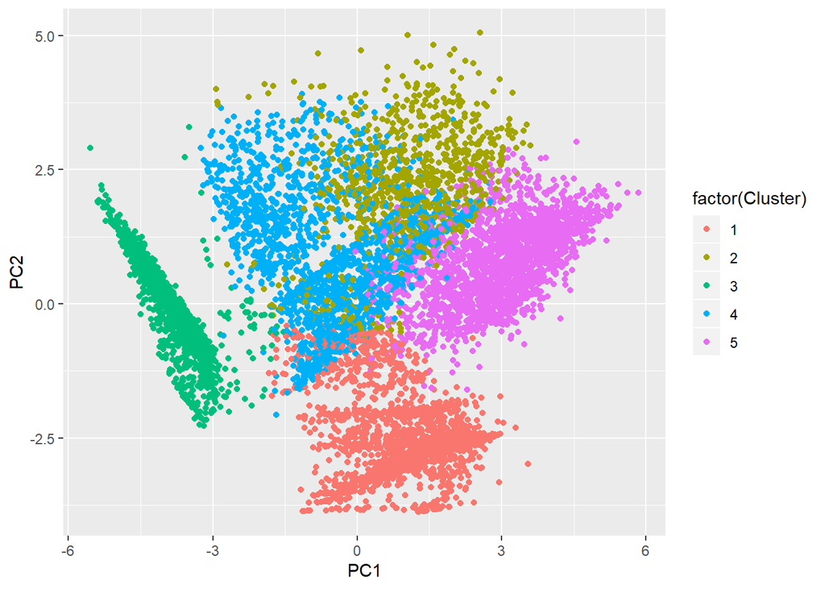

```r
cluster_scatter_5 <- cbind(credit_pca_data,pc_cluster_5$cluster)
names(cluster_scatter_5)[6] <- "Cluster"
ggplot(data=cluster_scatter_5, aes(x=PC1, y=PC2, color=factor(Cluster))) +
  geom_point()
```

```r
col_kpi=c('CASH_ADVANCE_TRX', 'PURCHASES_TRX', 'Monthly_Avg_PURCHASES',
          'Monthly_CASH_ADVANCE', 'LIMIT_USAGE', 'MIN_PAYMENTS_RATIO')
cluster_5 <- credit[,col_kpi]
cluster_5 <- cbind(cluster_5,binary_purchase_type)
cluster_5 <- cbind(cluster_5,cluster_df_5)
cluster_5[1:10,]
```

```
##    CASH_ADVANCE_TRX PURCHASES_TRX Monthly_Avg_PURCHASES Monthly_CASH_ADVANCE
## 1                 0             2              7.950000               0.0000
## 2                 4             0              0.000000             536.9121
## 3                 0            12             64.430833               0.0000
## 4                 1             1            124.916667              17.1490
## 5                 0             1              1.333333               0.0000
## 6                 0             8            111.106667               0.0000
## 7                 0            64            590.917500               0.0000
## 8                 0            12             36.350000               0.0000
## 9                 0             5             71.790833               0.0000
## 10                0             3            106.800000               0.0000
##    LIMIT_USAGE MIN_PAYMENTS_RATIO purchase_type.both_oneoff_installment
## 1   0.04090075          1.4465084                                     0
## 2   0.45749535          3.8262415                                     0
## 3   0.33268651          0.9916815                                     0
```

[output cut: 29 more lines]

```r
dim(cluster_5)
```

```
## [1] 8950   11
```

```r
cluster_group_by_5 <- group_by(cluster_5,cluster_df_5)
cluster_summ <- summarise(cluster_group_by_5,CASH_ADVANCE_TRX = mean(CASH_ADVANCE_TRX),PURCHASES_TRX= mean(PURCHASES_TRX),
                          Monthly_Avg_PURCHASES = mean(Monthly_Avg_PURCHASES),LIMIT_USAGE = mean(LIMIT_USAGE),Monthly_CASH_ADVANCE = mean(Monthly_CASH_ADVANCE),
                          MIN_PAYMENTS_RATIO = mean(MIN_PAYMENTS_RATIO),purchase_type.both_oneoff_installment = mean(purchase_type.both_oneoff_installment),
                          purchase_type.installment = mean(purchase_type.installment),purchase_type.none = mean(purchase_type.none),
                          purchase_type.oneoff = mean(purchase_type.oneoff))
cluster_summ <- t(cluster_summ)
colnames(cluster_summ) <- c("cluster-1","cluster-2","cluster-3","cluster-4","cluster-5")
cluster_summ
```

```
##                                        cluster-1    cluster-2    cluster-3
## cluster_df_5                           1.0000000   2.00000000 3.000000e+00
## CASH_ADVANCE_TRX                       0.4842797  10.51178451 6.454894e+00
## PURCHASES_TRX                         11.8967621  27.56677890 3.550864e-02
## Monthly_Avg_PURCHASES                 47.2438247 141.90647352 9.657167e-02
## LIMIT_USAGE                            0.2467329   0.59531009 5.762603e-01
## Monthly_CASH_ADVANCE                  19.1550482 252.43152371 1.851095e+02
## MIN_PAYMENTS_RATIO                    13.8619374   3.91707728 9.950170e+00
## purchase_type.both_oneoff_installment  0.0000000   0.87991021 0.000000e+00
## purchase_type.installment              1.0000000   0.10549944 1.679463e-02
## purchase_type.none                     0.0000000   0.00000000 9.798464e-01
## purchase_type.oneoff                   0.0000000   0.01459035 3.358925e-03
##                                          cluster-4   cluster-5
## cluster_df_5                           4.000000000   5.0000000
## CASH_ADVANCE_TRX                       2.648387097   0.1517137
## PURCHASES_TRX                          7.067741935  34.5357863
## Monthly_Avg_PURCHASES                 68.685725177 209.7761264
## LIMIT_USAGE                            0.377563147   0.2626540
## Monthly_CASH_ADVANCE                  73.635702543   3.9750396
## MIN_PAYMENTS_RATIO                     5.540102055   8.5730188
## purchase_type.both_oneoff_installment  0.003225806   1.0000000
## purchase_type.installment              0.000000000   0.0000000
## purchase_type.none                     0.000000000   0.0000000
## purchase_type.oneoff                   0.996774194   0.0000000
```

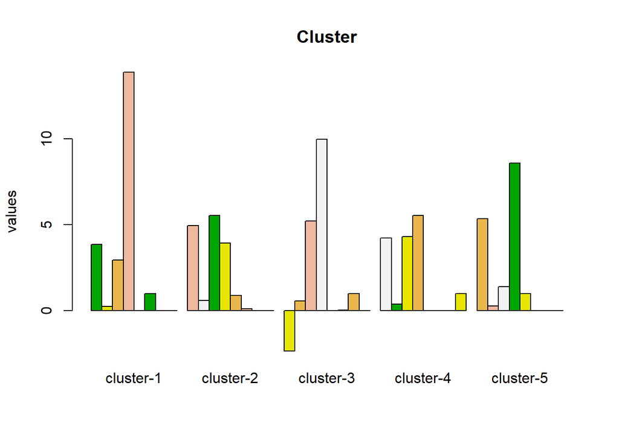

```r
cluster_summ <- cluster_summ[-c(1,2,3),]

cluster_summ <- t(cluster_summ)
cluster_summ <- as.data.frame(cluster_summ)
cluster_summ$Monthly_Avg_PURCHASES <- log(cluster_summ$Monthly_Avg_PURCHASES)
cluster_summ$Monthly_CASH_ADVANCE <- log(cluster_summ$Monthly_CASH_ADVANCE)
cluster_summ <- t(cluster_summ)
cluster_summ <- as.data.frame(cluster_summ)

barplot(as.matrix(cluster_summ), main="Cluster", ylab="values", beside=TRUE,
        col=terrain.colors(5))
```

```r
cluster_count <- cluster_scatter_5 %>%
                group_by(Cluster) %>%
                summarise(count_value = n())
cluster_count
```

```
## # A tibble: 5 x 2
##   Cluster count_value
##     <int>       <int>
## 1       1        2131
## 2       2         891
## 3       3        2084
## 4       4        1860
## 5       5        1984
```

```r
cluster_percentage <- cluster_count %>%
                      mutate(percentage = (count_value/sum(count_value)*100))
cluster_percentage
```

```
## # A tibble: 5 x 3
##   Cluster count_value percentage
##     <int>       <int>      <dbl>
## 1       1        2131      23.8
## 2       2         891       9.96
## 3       3        2084      23.3
## 4       4        1860      20.8
## 5       5        1984      22.2
```

**Insights on cluster-5**

## Marketing strategies that can be drawn from above analysis

We Came to know that we have 4 kind of customers

**1. Group 1**

- This group is has minimum paying ratio and using card for just oneoff transactions (may be for utility bills only). This group seems to be risky group.

**2. Group 2**

- This group is performing best among all as cutomers are maintaining good credit score and paying dues on time. – Giving rewards point will make them perform more purchases.

**3. Group 3**

- They have poor credit score and taking only cash on advance. We can target them by providing less interest rate on purchase transaction.

**4. Group 4**

- They are potential target customers who are paying dues and doing purchases and maintaining comparatively good credit score ) – we can increase credit limit or can lower down interest rate – Can be given premium card /loyality cards to increase transactions.

**Group 4 is the potential Target customer**